# Question

A 3D shape is produced with elliptical cross sections. As $x$ progresses from along the interval $[0,1]$, the cross section perpendicular to the $x$ axis will be an ellipse with axes (and radii) parallel to the $y$ and $z$ axes. The (maximum and minimum) radii are power functions with respect to $x$.

$$r_1(x) ~=~ x^{0.62}$$
$$r_2(x) ~=~ x^{3.05}$$

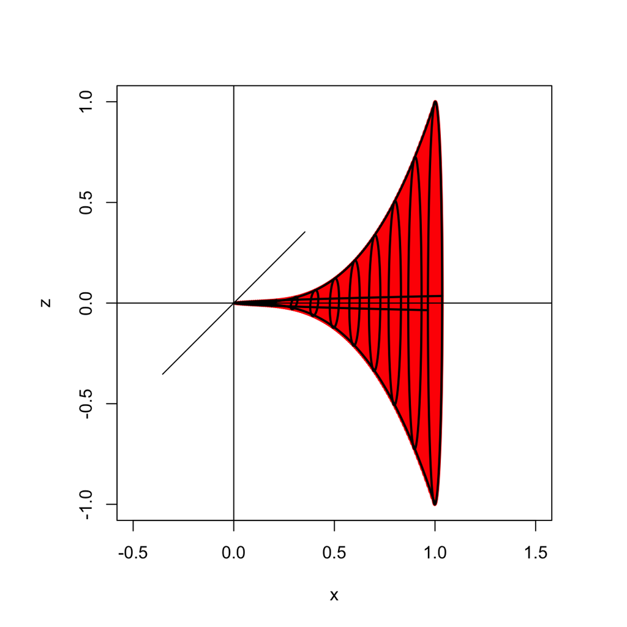

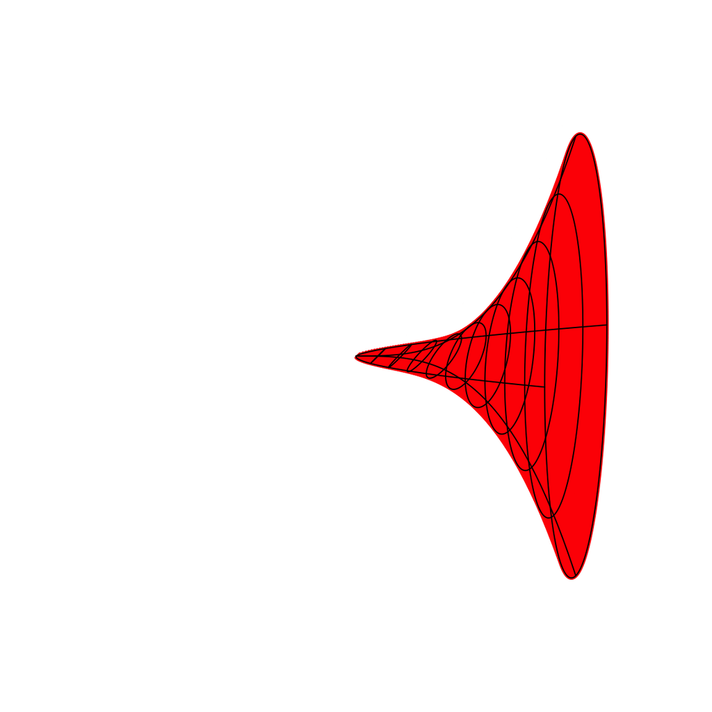

Find the volume of the shape. The tolerance is $\pm 0.01$ cubic units.

As a hint, I’ll remind you that the area of an ellipse is found by multiplying the radii by each other and pi: $A=\pi\cdot r_1 \cdot r_2$.

# Solution

Imagine breaking the 3D shape into a bunch of elliptical slices with infinitesimal thickness $dx$.

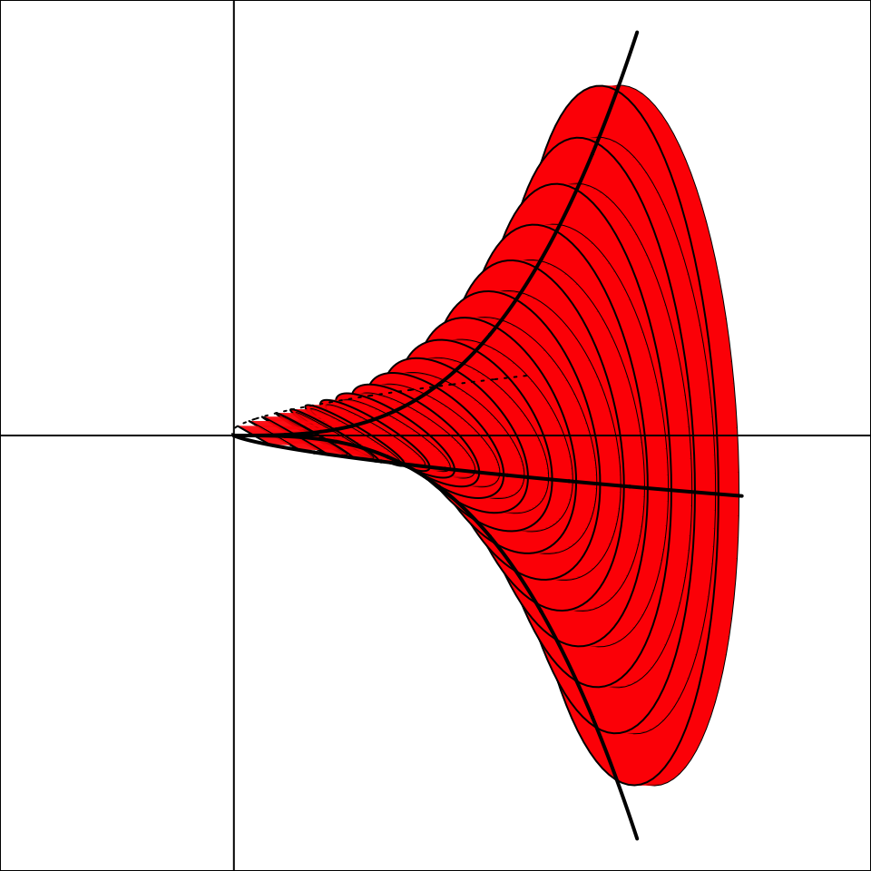

Each elliptical slab has an infinitesimal volume.

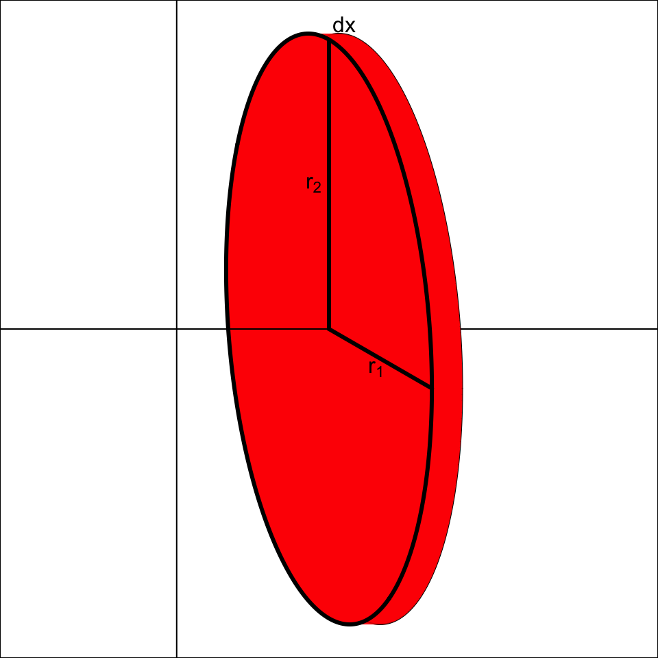

$$dV = \pi r_1 r_2 \, dx$$

$$dV = \pi x^{0.62} x^{3.05} \,
dx$$

$$dV = \pi x^{3.67} \, dx$$

To get the total volume, we need to **S**um up all the infinitesimal volumes as $x$ varies from 0 to 1.

$$V = \int_{x=0}^{x=1} dV$$

$$V = \int_{0}^{1} \pi x^{3.67} \,
dx$$

Find antiderivitive $g(x)$ so that $g'(x)=\pi x^{3.67}$ and $g(0)=0$ (so the constant of integration is 0).

$$g(x) = \frac{\pi}{4.67}
x^{4.67}$$

The total volume can be expressed in terms of function $g$.

$$V = g(1)-g(0)$$

Evaluate.

$$V = \frac{\pi}{4.67}
(1)^{4.67}-\frac{\pi}{4.67} (0)^{4.67}$$

$$V = \frac{\pi}{4.67}$$

$$V\approx 0.6727179$$

# Meta-information

extype: num exsolution: 0.6727179 exname: vol_ellipse_cs extol: 0.01